# **Análise Exploratória de Dados sobre Queimadas**

Queimadas #Queimadas

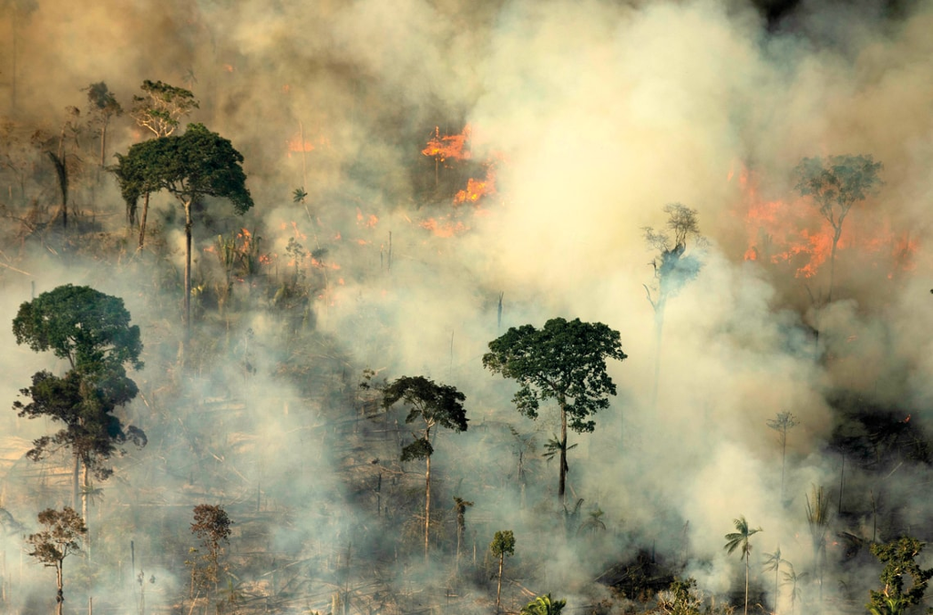

## **Resumo**

Incêndios florestais geram impactos sociais e ambientais nos locais onde ocorrem. A Energia Radiativa do Fogo (FRP) é uma técnica para quantificar a biomassa queimada usando dados de sensoriamento remoto.A FRP mede a energia radiante emitida por unidade de tempo pela vegetação queimada. A estimativa do total de biomassa queimada é realizada a partir da Energia Radiativa do Fogo (FRE), que é definida como a energia emitida pelo fogo como radiação eletromagnética durante o ciclo de vida da queimada e pode ser obtida a partir da integração temporal da FRP.

## **2. Descrição das variáveis**

```r
# Leitura dos dados
dados_queimadas_v1 <- read.csv("Focos_2021-06-26_2021-06-27.csv")
dados_queimadas_v1 %>%
  DT::datatable()
```

|  | datahora | satelite | pais | estado | municipio | bioma | diasemchuva | precipitacao | riscofogo | latitude | longitude | frp |
| --- | --- | --- | --- | --- | --- | --- | --- | --- | --- | --- | --- | --- |
| 1 | 2021/06/26 17:00:00 | AQUA_M-T | Brasil | RIO DE JANEIRO | SANTO ANTONIO DE PADUA | Mata Atlantica | 17 | 0 | -999 | -21.522 | -42.201 | 11.4 |
| 2 | 2021/06/26 17:00:00 | AQUA_M-T | Brasil | SAO PAULO | IBITINGA | Cerrado | 15 | 0 | 1 | -21.87 | -48.799 | 4.7 |
| 3 | 2021/06/26 17:00:00 | AQUA_M-T | Brasil | MATO GROSSO DO SUL | ANTONIO JOAO | Cerrado | 9 | 0 | 0.5 | -22.263 | -56.016 | 28.9 |
| 4 | 2021/06/26 17:00:00 | AQUA_M-T | Brasil | SAO PAULO | SANTA BARBARA D'OESTE | Mata Atlantica | 4 | 0.1 | 1 | -22.844 | -47.454 | 15.3 |
| 5 | 2021/06/26 17:00:00 | AQUA_M-T | Brasil | RIO DE JANEIRO | RIO DE JANEIRO | Mata Atlantica | -999 | 0 | 1 | -22.851 | -43.442 | 9.3 |
| 6 | 2021/06/26 17:00:00 | AQUA_M-T | Brasil | SAO PAULO | CAPIVARI | Mata Atlantica | 3 | 0.3 | 1 | -22.873 | -47.46 | 74.7 |
| 7 | 2021/06/26 17:00:00 | AQUA_M-T | Brasil | SAO PAULO | CAPIVARI | Mata Atlantica | 3 | 0.3 | 1 | -22.883 | -47.468 | 52.9 |
| 8 | 2021/06/26 17:00:00 | AQUA_M-T | Brasil | SAO PAULO | CAPIVARI | Mata Atlantica | 3 | 0.3 | 1 | -22.874 | -47.469 | 181.5 |
| 9 | 2021/06/26 17:00:00 | AQUA_M-T | Brasil | SAO PAULO | CAPIVARI | Mata Atlantica | 3 | 0.3 | 0.9 | -22.882 | -47.458 | 12.8 |
| 10 | 2021/06/26 17:00:00 | AQUA_M-T | Brasil | MATO GROSSO DO SUL | AMAMBAI | Mata Atlantica | 2 | 0 | 1 | -23.015 | -54.983 | 17.3 |

[output cut: 617 more lines]

## **3. Análise Exploratória dos dados**

```r
str(dados_queimadas_v1) %>%
  kable()
```

```
## 'data.frame':    627 obs. of  12 variables:
##  $ datahora    : chr  "2021/06/26 17:00:00" "2021/06/26 17:00:00" "2021/06/26 17:00:00" "2021/06/26 17:00:00" ...
##  $ satelite    : chr  "AQUA_M-T" "AQUA_M-T" "AQUA_M-T" "AQUA_M-T" ...
##  $ pais        : chr  "Brasil" "Brasil" "Brasil" "Brasil" ...
##  $ estado      : chr  "RIO DE JANEIRO" "SAO PAULO" "MATO GROSSO DO SUL" "SAO PAULO" ...
##  $ municipio   : chr  "SANTO ANTONIO DE PADUA" "IBITINGA" "ANTONIO JOAO" "SANTA BARBARA D'OESTE" ...
##  $ bioma       : chr  "Mata Atlantica" "Cerrado" "Cerrado" "Mata Atlantica" ...
##  $ diasemchuva : int  17 15 9 4 -999 3 3 3 3 2 ...
##  $ precipitacao: num  0 0 0 0.1 0 0.3 0.3 0.3 0.3 0 ...
##  $ riscofogo   : num  -999 1 0.5 1 1 1 1 1 0.9 1 ...
##  $ latitude    : num  -21.5 -21.9 -22.3 -22.8 -22.9 ...
##  $ longitude   : num  -42.2 -48.8 -56 -47.5 -43.4 ...
##  $ frp         : num  11.4 4.7 28.9 15.3 9.3 ...
```

[output not shown]

```r
summary(dados_queimadas_v1)
```

```
##    datahora           satelite             pais              estado
##  Length:627         Length:627         Length:627         Length:627
##  Class :character   Class :character   Class :character   Class :character
##  Mode  :character   Mode  :character   Mode  :character   Mode  :character
##
##
##
##
##   municipio            bioma            diasemchuva      precipitacao
##  Length:627         Length:627         Min.   :-999.0   Min.   :0.00000
##  Class :character   Class :character   1st Qu.:  14.0   1st Qu.:0.00000
##  Mode  :character   Mode  :character   Median :  24.0   Median :0.00000
##                                        Mean   :  21.9   Mean   :0.06109
##                                        3rd Qu.:  37.0   3rd Qu.:0.00000
##                                        Max.   :  59.0   Max.   :3.20000
##                                        NA's   :185      NA's   :185
##    riscofogo          latitude         longitude           frp
##  Min.   :-999.00   Min.   :-25.865   Min.   :-72.32   Min.   :   4.60
##  1st Qu.:   0.80   1st Qu.:-14.695   1st Qu.:-53.85   1st Qu.:  14.45
##  Median :   1.00   Median :-11.747   Median :-49.72   Median :  24.20
##  Mean   : -10.43   Mean   :-12.304   Mean   :-50.26   Mean   :  74.76
##  3rd Qu.:   1.00   3rd Qu.: -9.633   3rd Qu.:-46.94   3rd Qu.:  54.80
##  Max.   :   1.00   Max.   :  3.875   Max.   :-35.59   Max.   :5013.60
##  NA's   :185
```

Verificamos que existem dados faltantes e outliers

Análise dias sem chuva

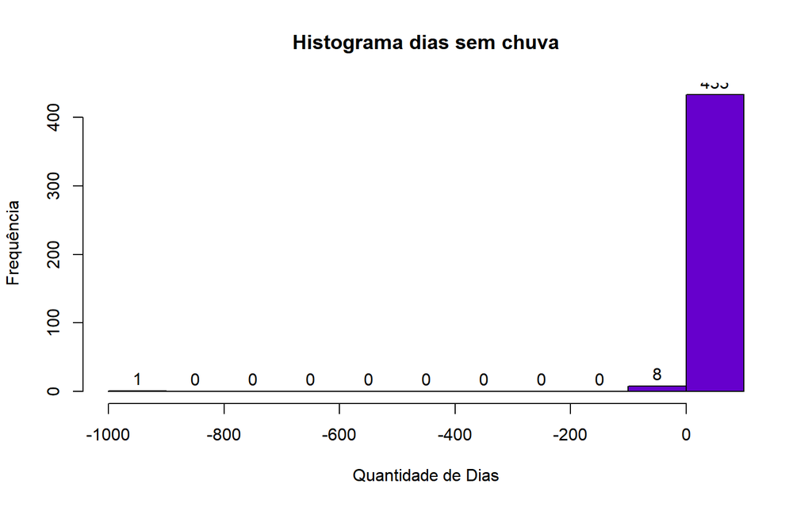

```r
hist(dados_queimadas_v1$diasemchuva,
     main = "Histograma dias sem chuva",
     xlab = "Quantidade de Dias",
     ylab = "Frequência",
     col = "#6600cc",
     labels = TRUE)
```

Análise precipitação

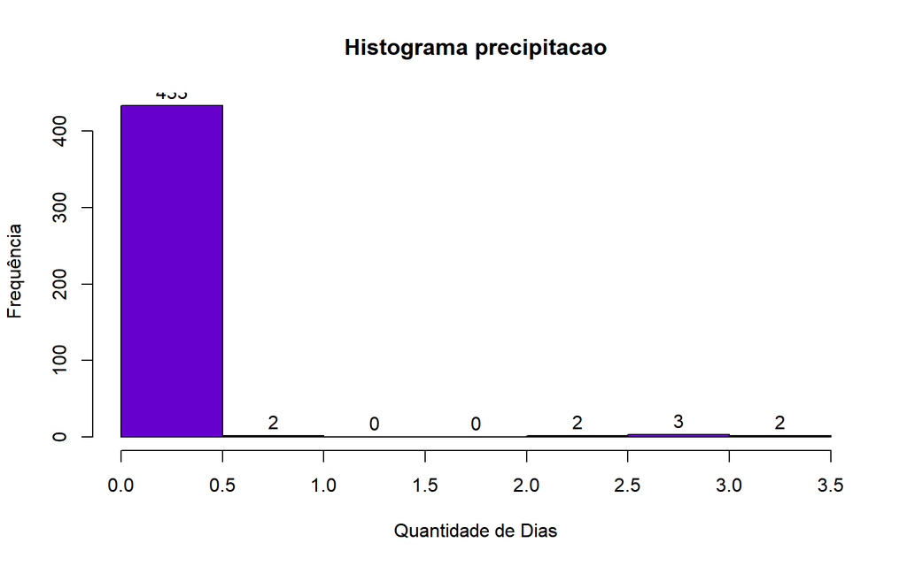

```r
hist(dados_queimadas_v1$precipitacao,
     main = "Histograma precipitacao",
     xlab = "Quantidade de Dias",
     ylab = "Frequência",
     col = "#6600cc",
     labels = TRUE)
```

Análise riscofogo

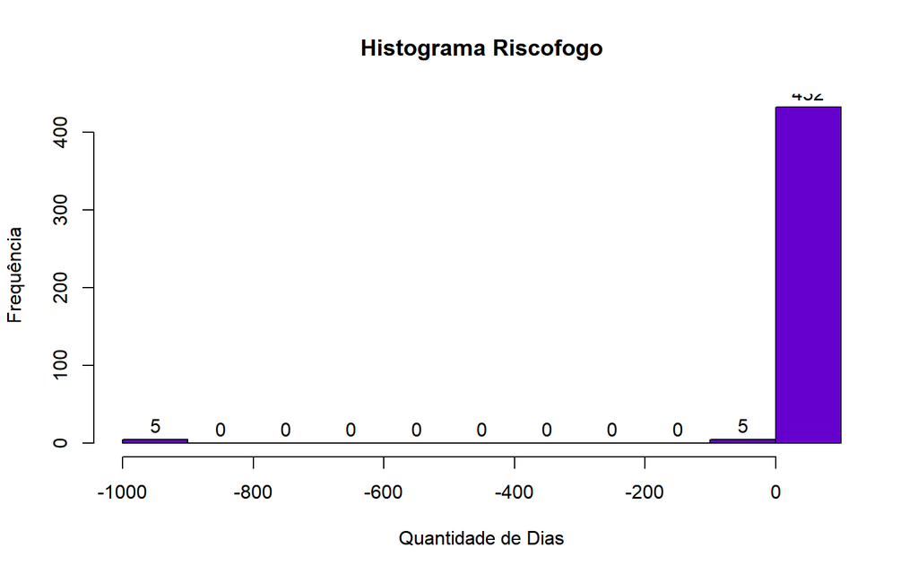

```r
hist(dados_queimadas_v1$riscofogo,
     main = "Histograma Riscofogo",
     xlab = "Quantidade de Dias",
     ylab = "Frequência",
     col = "#6600cc",
     labels = TRUE)
```

#Removendo outliers negativos

```r
dados_queimadas_v2 =filter(dados_queimadas_v1,diasemchuva >=0 | is.na(diasemchuva),riscofogo >=0 | is.na(riscofogo))
```

Analise dos dados após a retirada dos outliers

```r
summary(dados_queimadas_v2)
```

```
##    datahora           satelite             pais              estado
##  Length:621         Length:621         Length:621         Length:621
##  Class :character   Class :character   Class :character   Class :character
##  Mode  :character   Mode  :character   Mode  :character   Mode  :character
##
##
##
##
##   municipio            bioma            diasemchuva     precipitacao
##  Length:621         Length:621         Min.   : 0.00   Min.   :0.00000
##  Class :character   Class :character   1st Qu.:14.00   1st Qu.:0.00000
##  Mode  :character   Mode  :character   Median :24.00   Median :0.00000
##                                        Mean   :24.27   Mean   :0.06193
##                                        3rd Qu.:37.00   3rd Qu.:0.00000
##                                        Max.   :59.00   Max.   :3.20000
##                                        NA's   :185     NA's   :185
##    riscofogo         latitude         longitude           frp
##  Min.   :0.0000   Min.   :-25.865   Min.   :-72.32   Min.   :   4.60
##  1st Qu.:0.8000   1st Qu.:-14.645   1st Qu.:-54.00   1st Qu.:  14.50
##  Median :1.0000   Median :-11.721   Median :-49.77   Median :  24.30
##  Mean   :0.8782   Mean   :-12.241   Mean   :-50.30   Mean   :  75.34
##  3rd Qu.:1.0000   3rd Qu.: -9.568   3rd Qu.:-46.94   3rd Qu.:  55.00
##  Max.   :1.0000   Max.   :  3.875   Max.   :-35.59   Max.   :5013.60
##  NA's   :185
```

Análise dias sem chuva

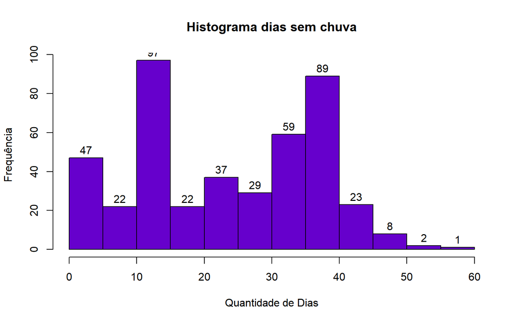

```r
hist(dados_queimadas_v2$diasemchuva,
     main = "Histograma dias sem chuva",
     xlab = "Quantidade de Dias",
     ylab = "Frequência",
     col = "#6600cc",
     labels = TRUE)
```

Análise riscofogo

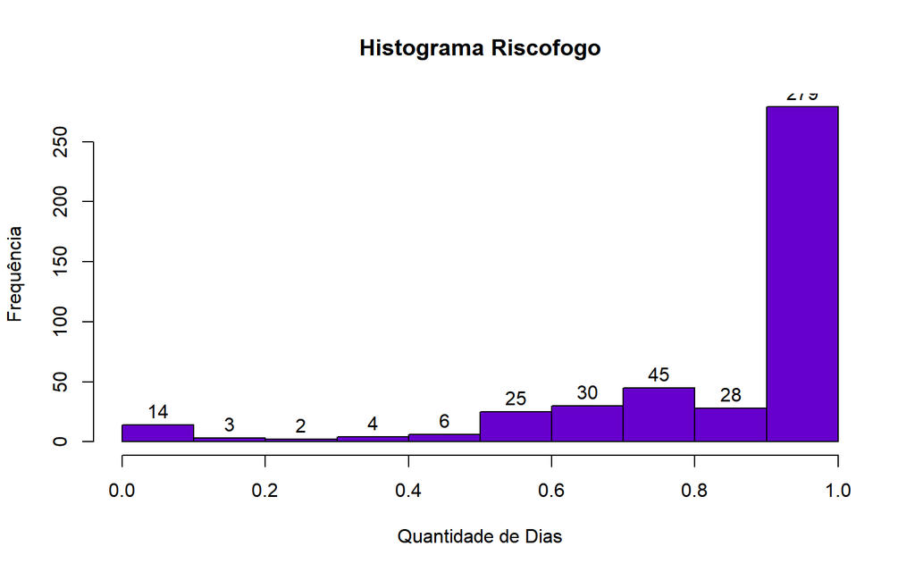

```r
hist(dados_queimadas_v2$riscofogo,
     main = "Histograma Riscofogo",
     xlab = "Quantidade de Dias",
     ylab = "Frequência",
     col = "#6600cc",
     labels = TRUE)
```

Análise precipitação

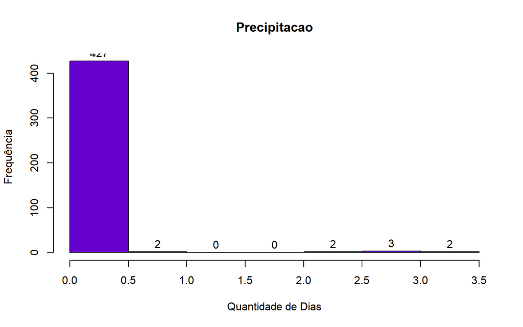

```r
hist(dados_queimadas_v2$precipitacao ,
     main = "Precipitacao",
     xlab = "Quantidade de Dias",
     ylab = "Frequência",
     col = "#6600cc",
     labels = TRUE)
```

Análise FRP (verificar se faz sentido!!!)

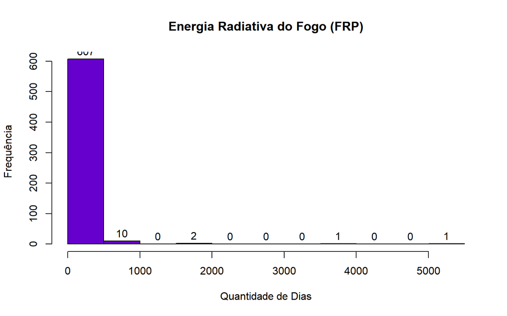

```r
hist(dados_queimadas_v2$frp ,
     main = "Energia Radiativa do Fogo (FRP)",
     xlab = "Quantidade de Dias",
     ylab = "Frequência",
     col = "#6600cc",
     labels = TRUE)
```

```r
sapply(dados_queimadas_v2, function(x)sum(is.na(x)))
```

```
##     datahora     satelite         pais       estado    municipio        bioma
##            0            0            0            0            0            0
##  diasemchuva precipitacao    riscofogo     latitude    longitude          frp
##          185          185          185            0            0            0
```

```r
sum(is.na(dados_queimadas_v2)) %>%
  kable()
```

| x |
| --- |
| 555 |

## Aplicando Imputação em Valores Missing Usando Método PMM (Predictive Mean Matching)

1º Encontrar as variáveis com dados do tipo caracter e pegar o nome das colunas

```r
chr_col <- as.integer(0)
chrnames <- names(Filter(is.character, dados_queimadas_v2))
chrnames
```

```
## [1] "datahora"  "satelite"  "pais"      "estado"    "municipio" "bioma"
```

```r
k = 1
```

2º Encontrando o indice dessas colunas

```r
for(i in chrnames){
  while (k <= 6){ #nesse dataset temos apenas 6
    grep(i, colnames(dados_queimadas_v2))
    chr_col[k] <- grep(i, colnames(dados_queimadas_v2))
    k = k + 1
    break
  }
}
```

Colunas que são do tipo caracter

```r
chr_col
```

```
## [1] 1 2 3 4 5 6
```

Imputação Definindo a regra de imputação

```r
regra_imputacao <- mice((dados_queimadas_v2[,-c(chr_col)]),
                        m = 1,
                        maxit = 50,
                        meth = 'pmm',)
```

Aplicando a regra de imputação

```r
total_data <- complete(regra_imputacao, 1)
View(total_data)
sum(is.na(total_data))
```

```
## [1] 0
```

Juntar novamente as variáveis categóricas ao dataset

```r
dados_queimadas_v2_final <- cbind(dados_queimadas_v2[,c(chr_col)],total_data )#incluindo as colunas com fator o c esta sem o sinal de negativo
View(dados_queimadas_v2_final)
View(dados_queimadas_v2)
sum(is.na(dados_queimadas_v2_final))
```

```
## [1] 0
```

```r
summary(dados_queimadas_v2_final)
```

```
##    datahora           satelite             pais              estado
##  Length:621         Length:621         Length:621         Length:621
##  Class :character   Class :character   Class :character   Class :character
##  Mode  :character   Mode  :character   Mode  :character   Mode  :character
##
##
##
##   municipio            bioma            diasemchuva     precipitacao
##  Length:621         Length:621         Min.   : 0.00   Min.   :0.00000
##  Class :character   Class :character   1st Qu.:14.00   1st Qu.:0.00000
##  Mode  :character   Mode  :character   Median :25.00   Median :0.00000
##                                        Mean   :24.39   Mean   :0.05717
##                                        3rd Qu.:37.00   3rd Qu.:0.00000
##                                        Max.   :59.00   Max.   :3.20000
##    riscofogo         latitude         longitude           frp
##  Min.   :0.0000   Min.   :-25.865   Min.   :-72.32   Min.   :   4.60
##  1st Qu.:0.8000   1st Qu.:-14.645   1st Qu.:-54.00   1st Qu.:  14.50
##  Median :1.0000   Median :-11.721   Median :-49.77   Median :  24.30
##  Mean   :0.8688   Mean   :-12.241   Mean   :-50.30   Mean   :  75.34
##  3rd Qu.:1.0000   3rd Qu.: -9.568   3rd Qu.:-46.94   3rd Qu.:  55.00
##  Max.   :1.0000   Max.   :  3.875   Max.   :-35.59   Max.   :5013.60
```

Análise dias sem chuva

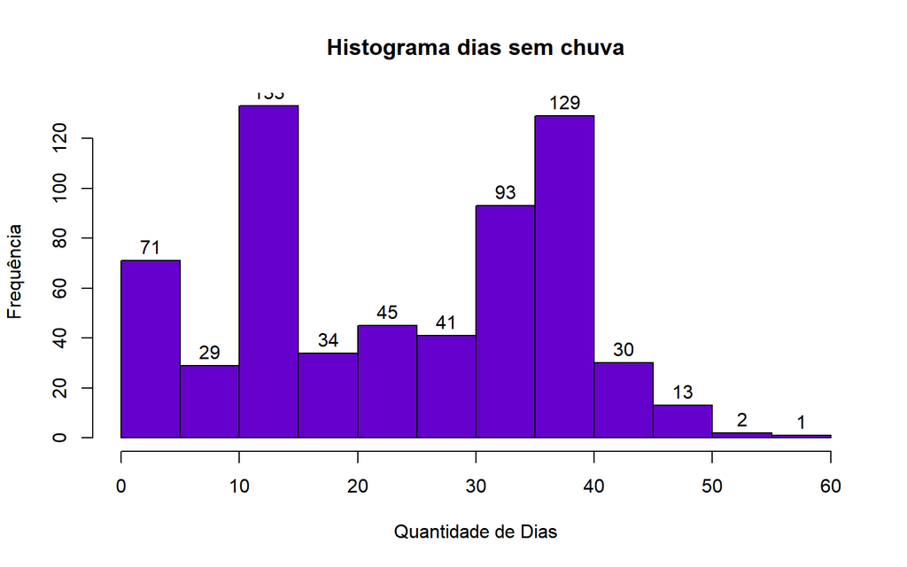

```r
hist(dados_queimadas_v2_final$diasemchuva,
     main = "Histograma dias sem chuva",
     xlab = "Quantidade de Dias",
     ylab = "Frequência",
     col = "#6600cc",
     labels = TRUE)
```

Análise riscofogo

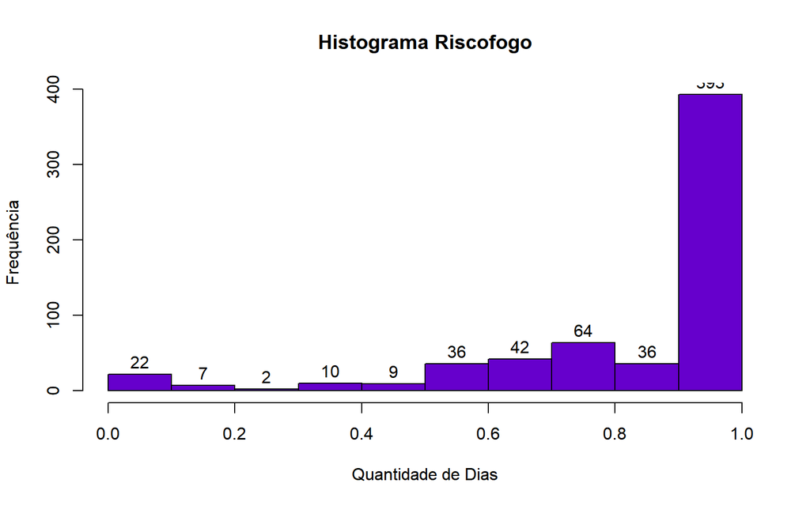

```r
hist(dados_queimadas_v2_final$riscofogo,
     main = "Histograma Riscofogo",
     xlab = "Quantidade de Dias",
     ylab = "Frequência",
     col = "#6600cc",
     labels = TRUE)
```

Análise precipitação

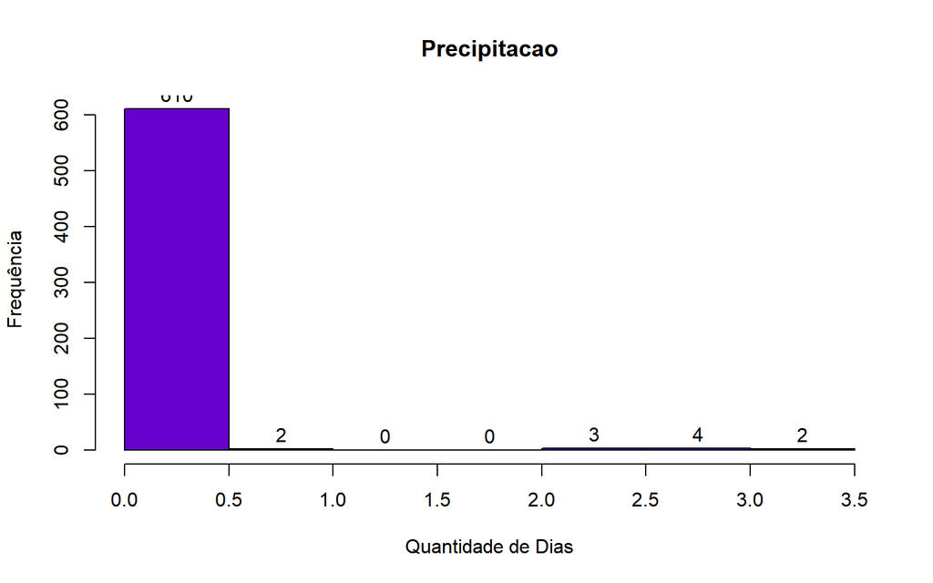

```r
hist(dados_queimadas_v2_final$precipitacao ,
     main = "Precipitacao",
     xlab = "Quantidade de Dias",
     ylab = "Frequência",
     col = "#6600cc",
     labels = TRUE)
```

Análise FRP (verificar se faz sentido!!!)

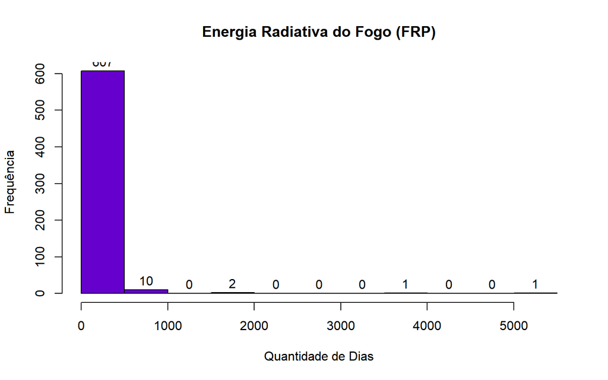

```r
hist(dados_queimadas_v2_final$frp ,
     main = "Energia Radiativa do Fogo (FRP)",
     xlab = "Quantidade de Dias",
     ylab = "Frequência",
     col = "#6600cc",
     labels = TRUE)
```

BoxPlot

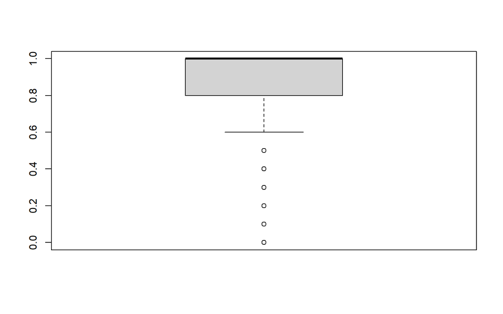

```r
boxplot(dados_queimadas_v2_final$riscofogo)
```

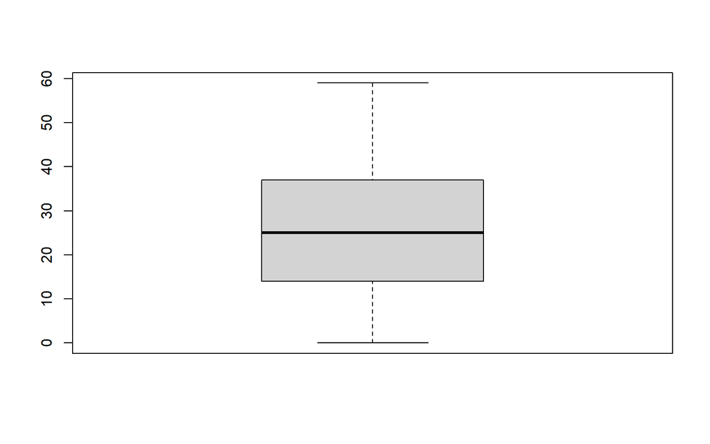

```r
boxplot(dados_queimadas_v2_final$diasemchuva)
```

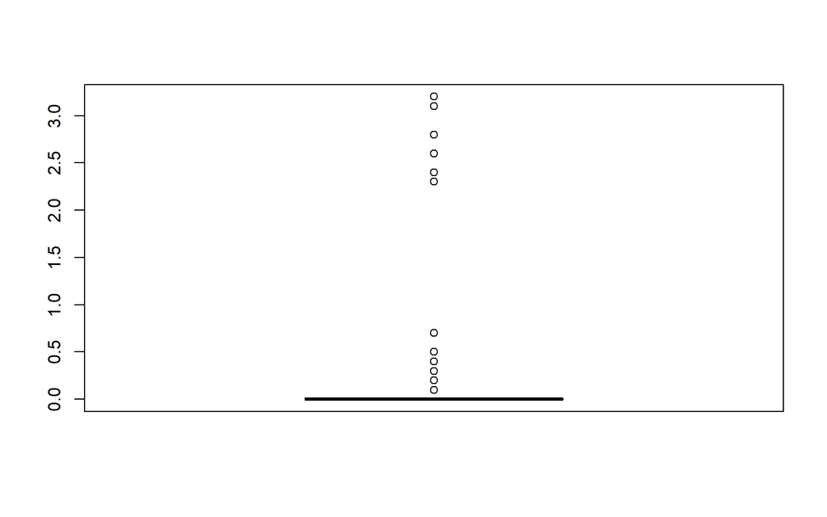

```r
boxplot(dados_queimadas_v2_final$precipitacao)
```

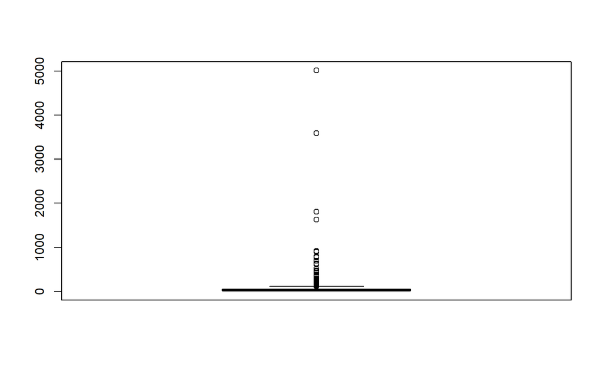

```r
boxplot(dados_queimadas_v2_final$frp)
```

calculando a média de dias sem chuva por município

```r
diaschuva_municipio_antes<-aggregate(data = dados_queimadas_v2, diasemchuva ~ municipio, mean)
diaschuva_municipio_antes<-aggregate(data = dados_queimadas_v2_final, diasemchuva ~ municipio, mean)
```

calculando a média de dias sem chuva por estado

```r
diaschuva_estado_antes<- aggregate(data = dados_queimadas_v2, diasemchuva ~ estado, mean)
diaschuva_estado_depois<- aggregate(data = dados_queimadas_v2_final, diasemchuva ~ estado, mean)
```

calculando vários juntos

```r
aggregate(data = dados_queimadas_v2_final, cbind(diasemchuva,precipitacao,riscofogo,frp) ~ estado, mean)
```

```
##                 estado diasemchuva precipitacao riscofogo       frp
## 1                 ACRE    18.20000 0.0600000000 0.5800000  21.04000
## 2             AMAZONAS    23.83333 0.0000000000 0.3833333  16.23333
## 3                BAHIA    38.61111 0.0222222222 0.9555556  25.81667
## 4                CEARA    33.00000 0.0000000000 1.0000000   6.00000
## 5       ESPIRITO SANTO    13.66667 0.0000000000 1.0000000 104.96667
## 6                GOIAS    15.68750 0.0000000000 0.9687500  34.74063
## 7             MARANHAO    20.65854 0.0780487805 0.9097561  48.02195
## 8          MATO GROSSO    29.42922 0.0506849315 0.8328767 149.15936
## 9   MATO GROSSO DO SUL    12.15385 0.2923076923 0.8076923  35.56923
## 10        MINAS GERAIS    16.89583 0.0000000000 0.9854167  25.56250
## 11                PARA     8.04000 0.4440000000 0.3720000  27.36400
## 12             PARAIBA    38.66667 0.0000000000 1.0000000  15.00000
## 13              PARANA    10.00000 0.0000000000 0.6181818  29.08182
## 14          PERNAMBUCO    17.33333 0.0000000000 1.0000000  13.30000
## 15               PIAUI    26.47222 0.0166666667 0.9611111  34.06111
## 16      RIO DE JANEIRO    21.33333 0.0000000000 1.0000000  32.90000
## 17 RIO GRANDE DO NORTE    30.75000 0.0000000000 1.0000000  39.60000
## 18            RONDONIA    16.80000 0.3000000000 0.4600000  20.36000
## 19             RORAIMA     4.00000 0.5000000000 0.5000000   7.70000
## 20           SAO PAULO    13.18519 0.0518518519 0.9629630  67.02963
## 21           TOCANTINS    28.88393 0.0008928571 0.9803571  33.66339
```

```r
aggregate(data = dados_queimadas_v2_final, cbind(diasemchuva,precipitacao,riscofogo,frp) ~ municipio, mean)
```

```
##                       municipio diasemchuva precipitacao riscofogo        frp
## 1                    ABAETETUBA    0.000000  2.350000000 0.0000000  15.300000
## 2                       ABAIARA   33.000000  0.000000000 1.0000000   6.000000
## 3                   ABREULANDIA   42.000000  0.000000000 1.0000000  20.000000
## 4                         ACARA    2.000000  0.000000000 0.0000000  22.600000
## 5                      AGUA BOA   15.000000  0.000000000 1.0000000  33.600000
## 6                 ALDEIAS ALTAS   26.000000  0.000000000 1.0000000  18.400000
## 7                         ALMAS   36.400000  0.000000000 0.9600000  61.460000
## 8                 ALTA FLORESTA   25.000000  1.966666667 0.6666667  59.933333
## 9                        ALTAIR   15.000000  0.000000000 1.0000000  91.983333
## 10               ALTO BOA VISTA   36.000000  0.000000000 1.0000000  71.900000
## 11                ALTO PARNAIBA   16.000000  0.000000000 1.0000000  83.300000
## 12                      AMAJARI    4.000000  0.500000000 0.5000000   7.700000
## 13                      AMAMBAI    2.000000  0.000000000 1.0000000  17.300000
## 14                 ANTONIO JOAO    9.000000  0.000000000 0.5000000  28.900000
```

[output cut: 210 more lines]

Variancia

```r
var(dados_queimadas_v2_final$riscofogo)
```

```
## [1] 0.05228056
```

```r
var(dados_queimadas_v2_final$diasemchuva)
```

```
## [1] 183.9776
```

```r
var(dados_queimadas_v2_final$precipitacao)
```

```
## [1] 0.1092268
```

```r
var(dados_queimadas_v2_final$frp)
```

```
## [1] 78911.65
```

Desvio Padrão

```r
sd(dados_queimadas_v2_final$riscofogo)
```

```
## [1] 0.2286494
```

```r
sd(dados_queimadas_v2_final$diasemchuva)
```

```
## [1] 13.56384
```

```r
sd(dados_queimadas_v2_final$precipitacao)
```

```
## [1] 0.3304948
```

```r
sd(dados_queimadas_v2_final$frp)
```

```
## [1] 280.9122
```

Coeficiente de Assimetria

```r
skewness(dados_queimadas_v2_final$diasemchuva)
```

```
## [1] -0.1434838
```

```r
skewness(dados_queimadas_v2_final$precipitacao )
```

```
## [1] 7.647052
```

```r
skewness(dados_queimadas_v2_final$riscofogo)
```

```
## [1] -2.09894
```

```r
skewness(dados_queimadas_v2_final$frp)
```

```
## [1] 12.77149
```

Curtose grau de achatamento em relação a normal Padrão

```r
kurtosis(dados_queimadas_v2_final$diasemchuva)
```

```
## [1] -1.218481
```

```r
kurtosis(dados_queimadas_v2_final$riscofogo)
```

```
## [1] 4.096687
```

```r
kurtosis(dados_queimadas_v2_final$precipitacao )
```

```
## [1] 59.93042
```

```r
kurtosis(dados_queimadas_v2_final$frp)
```

```
## [1] 194.5906
```

Diasemchuva X riscofogo(correlação fraca positiva)

```r
x = dados_queimadas_v2_final$diasemchuva
y = dados_queimadas_v2_final$riscofogo
cor(x,y)
```

```
## [1] 0.3379485
```

Precipitacao X riscofogo (correlação fraca negativa)

```r
x = dados_queimadas_v2_final$precipitacao
y = dados_queimadas_v2_final$riscofogo
cor(x,y)
```

```
## [1] -0.3521952
```

frp X riscofogo (correlação fraca negativa)

```r
x = dados_queimadas_v2_final$frp
y = dados_queimadas_v2_final$riscofogo
cor(x,y)
```

```
## [1] -0.208772
```

Correlacao

```r
cor(dados_queimadas_v2_final[c( "diasemchuva", "precipitacao", "riscofogo", "latitude","longitude","frp" )])
```

```
##               diasemchuva precipitacao  riscofogo    latitude    longitude
## diasemchuva   1.000000000  -0.17131824  0.3379485  0.13194133  0.009535746
## precipitacao -0.171318240   1.00000000 -0.3521952  0.12821318 -0.080443961
## riscofogo     0.337948463  -0.35219518  1.0000000 -0.23502190  0.428353617
## latitude      0.131941328   0.12821318 -0.2350219  1.00000000  0.074502478
## longitude     0.009535746  -0.08044396  0.4283536  0.07450248  1.000000000
## frp          -0.066387703   0.19645315 -0.2087720 -0.01971455 -0.113175719
##                      frp
## diasemchuva  -0.06638770
## precipitacao  0.19645315
## riscofogo    -0.20877198
## latitude     -0.01971455
## longitude    -0.11317572
## frp           1.00000000
```

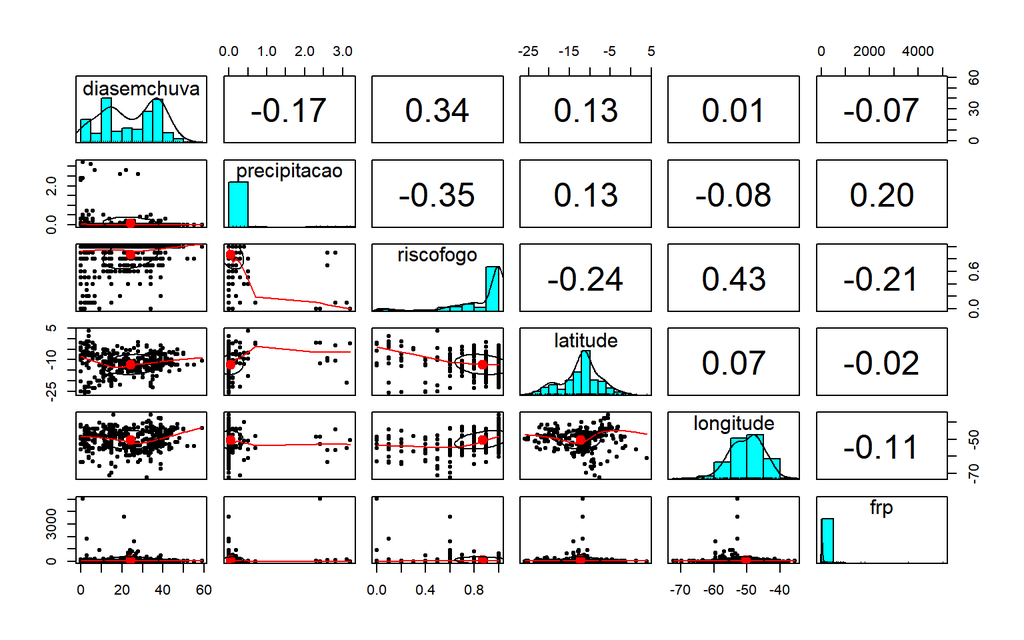

```r
pairs.panels(dados_queimadas_v2_final[c( "diasemchuva", "precipitacao", "riscofogo", "latitude","longitude","frp" )])
```

Checando se a variável alvo está balanceada (*******colocar o indicador de queimada e ou tipo vegetação, região, etc) Muita concentração em 1

```r
prop.table(table(dados_queimadas_v2_final$riscofogo)) * 100
```

```
##
##          0        0.1        0.2        0.3        0.4        0.5        0.6
##  1.2882448  2.2544283  1.1272142  0.3220612  1.6103060  1.4492754  5.7971014
##        0.7        0.8        0.9          1
##  6.7632850 10.3059581  5.7971014 63.2850242
```

```r
prop.table(table(dados_queimadas_v2_final$diasemchuva)) * 100
```

```
##
##          0          1          2          3          4          5          6
##  2.0933977  0.8051530  2.7375201  3.0595813  2.4154589  0.3220612  1.4492754
##          7          8          9         10         11         12         13
##  1.2882448  0.4830918  0.9661836  0.4830918  4.5088567  1.4492754  0.3220612
##         14         15         16         17         18         19         20
##  2.7375201 12.3993559  1.4492754  0.9661836  0.8051530  1.4492754  0.8051530
##         21         22         23         24         25         26         27
##  1.6103060  1.9323671  1.4492754  1.2882448  0.9661836  1.6103060  0.8051530
##         28         29         30         31         32         33         34
##  2.0933977  0.9661836  1.1272142  0.6441224  2.0933977  1.4492754  6.1191626
##         35         36         37         38         39         40         41
##  4.6698873  1.7713366  1.7713366  4.3478261 11.4331723  1.4492754  1.6103060
##         42         43         44         45         46         47         48
##  0.8051530  0.9661836  1.1272142  0.3220612  0.9661836  0.6441224  0.1610306
##         50         52         55         59
##  0.3220612  0.1610306  0.1610306  0.1610306
```

Muita concentração em 0

```r
prop.table(table(dados_queimadas_v2_final$precipitacao)) * 100
```

```
##
##          0        0.1        0.2        0.3        0.4        0.5        0.7
## 90.9822866  2.8985507  1.7713366  1.4492754  0.4830918  0.6441224  0.3220612
##        2.3        2.4        2.6        2.8        3.1        3.2
##  0.1610306  0.3220612  0.3220612  0.3220612  0.1610306  0.1610306
```

Antes e depois da imputação

```r
as.data.frame(table(dados_queimadas_v2$riscofogo))
```

```
##    Var1 Freq
## 1     0    5
## 2   0.1    9
## 3   0.2    3
## 4   0.3    2
## 5   0.4    4
## 6   0.5    6
## 7   0.6   25
## 8   0.7   30
## 9   0.8   45
## 10  0.9   28
## 11    1  279
```

```r
as.data.frame(table(dados_queimadas_v2_final$riscofogo))
```

```
##    Var1 Freq
## 1     0    8
## 2   0.1   14
## 3   0.2    7
## 4   0.3    2
## 5   0.4   10
## 6   0.5    9
## 7   0.6   36
## 8   0.7   42
## 9   0.8   64
## 10  0.9   36
## 11    1  393
```

Transformando dados que estão como character mas podem ter comportamento de fatores Bioma

```r
dados_queimadas_v3_final <-data.frame(dados_queimadas_v2_final)
dados_queimadas_v3_final$bioma <- as.factor(dados_queimadas_v3_final$bioma)
dados_queimadas_v3_final$diasemchuva<- as.numeric(dados_queimadas_v3_final$diasemchuva)
```

```r
str(dados_queimadas_v3_final)
```

```
## 'data.frame':    621 obs. of  12 variables:
##  $ datahora    : chr  "2021/06/26 17:00:00" "2021/06/26 17:00:00" "2021/06/26 17:00:00" "2021/06/26 17:00:00" ...
##  $ satelite    : chr  "AQUA_M-T" "AQUA_M-T" "AQUA_M-T" "AQUA_M-T" ...
##  $ pais        : chr  "Brasil" "Brasil" "Brasil" "Brasil" ...
##  $ estado      : chr  "SAO PAULO" "MATO GROSSO DO SUL" "SAO PAULO" "SAO PAULO" ...
##  $ municipio   : chr  "IBITINGA" "ANTONIO JOAO" "SANTA BARBARA D'OESTE" "CAPIVARI" ...
##  $ bioma       : Factor w/ 5 levels "Amazonia","Caatinga",..: 3 3 4 4 4 4 4 4 4 4 ...
##  $ diasemchuva : num  15 9 4 3 3 3 3 2 7 6 ...
##  $ precipitacao: num  0 0 0.1 0.3 0.3 0.3 0.3 0 0 0 ...
##  $ riscofogo   : num  1 0.5 1 1 1 1 0.9 1 0.8 0.8 ...
##  $ latitude    : num  -21.9 -22.3 -22.8 -22.9 -22.9 ...
##  $ longitude   : num  -48.8 -56 -47.5 -47.5 -47.5 ...
##  $ frp         : num  4.7 28.9 15.3 74.7 52.9 ...
```

```r
indice_divisao_dos_dados <- sample(x = nrow(dados_queimadas_v3_final),
                                   size = 0.6 * nrow(dados_queimadas_v3_final),
                                   replace = FALSE)#amostra sem reposição
```

Separando os dados

```r
dados_treino <- dados_queimadas_v3_final[indice_divisao_dos_dados ,]
dados_teste <- dados_queimadas_v3_final[-indice_divisao_dos_dados ,]
```

## ** Treinamento do modelo de regressão linear n1 **

```r
model_v1 <- lm(riscofogo ~ diasemchuva +precipitacao+ latitude + longitude + frp, data = dados_treino[,-c(1:6)] )
```

```r
previsao_treino_v1 <- predict(model_v1)
```

Testando o modelo Nº1

```r
teste_v1 <- dados_teste[,-c(1:6,9)] #retirando colunas de character e target
View(dados_teste)
View(teste_v1)
previsao_teste_v1 <- predict(model_v1,teste_v1)
```

```r
summary(model_v1)
```

```
##
## Call:
## lm(formula = riscofogo ~ diasemchuva + precipitacao + latitude +
##     longitude + frp, data = dados_treino[, -c(1:6)])
##
## Residuals:
##      Min       1Q   Median       3Q      Max
## -0.63399 -0.07627  0.02326  0.10180  0.44081
##
## Coefficients:
##                Estimate Std. Error t value Pr(>|t|)
## (Intercept)   1.545e+00  8.415e-02  18.362  < 2e-16 ***
## diasemchuva   4.878e-03  6.164e-04   7.914 2.99e-14 ***
## precipitacao -5.146e-02  3.269e-02  -1.574  0.11629
## latitude     -1.603e-02  1.811e-03  -8.847  < 2e-16 ***
## longitude     1.939e-02  1.634e-03  11.862  < 2e-16 ***
## frp          -9.718e-05  2.577e-05  -3.771  0.00019 ***
## ---
## Signif. codes:  0 '***' 0.001 '**' 0.01 '*' 0.05 '.' 0.1 ' ' 1
##
## Residual standard error: 0.1588 on 366 degrees of freedom
## Multiple R-squared:  0.4538, Adjusted R-squared:  0.4463
## F-statistic: 60.81 on 5 and 366 DF,  p-value: < 2.2e-16
```

Detectando a colinearidade: quando duas ou mais variaveis preditivas são altamente correlacionadas aumenta o erro padrão obtendo estimativas instáveis avaliar valores maiores que 5

```r
kable(vif(model_v1 ),align='c')
```

|  | x |
| --- | --- |
| diasemchuva | 1.048761 |
| precipitacao | 1.178935 |
| latitude | 1.055471 |
| longitude | 1.035011 |
| frp | 1.137639 |

Fazendo seleção de atributos com o método Akaike(AIC)

```r
step<-stepAIC(model_v1, direction='both', trace=FALSE)
summary(step)
```

```
##
## Call:
## lm(formula = riscofogo ~ diasemchuva + precipitacao + latitude +
##     longitude + frp, data = dados_treino[, -c(1:6)])
##
## Residuals:
##      Min       1Q   Median       3Q      Max
## -0.63399 -0.07627  0.02326  0.10180  0.44081
##
## Coefficients:
##                Estimate Std. Error t value Pr(>|t|)
## (Intercept)   1.545e+00  8.415e-02  18.362  < 2e-16 ***
## diasemchuva   4.878e-03  6.164e-04   7.914 2.99e-14 ***
## precipitacao -5.146e-02  3.269e-02  -1.574  0.11629
## latitude     -1.603e-02  1.811e-03  -8.847  < 2e-16 ***
## longitude     1.939e-02  1.634e-03  11.862  < 2e-16 ***
## frp          -9.718e-05  2.577e-05  -3.771  0.00019 ***
## ---
## Signif. codes:  0 '***' 0.001 '**' 0.01 '*' 0.05 '.' 0.1 ' ' 1
##
## Residual standard error: 0.1588 on 366 degrees of freedom
## Multiple R-squared:  0.4538, Adjusted R-squared:  0.4463
## F-statistic: 60.81 on 5 and 366 DF,  p-value: < 2.2e-16
```

Incluindo uma coluna com os valores previstos no dataset

```r
dados_teste_com_previsoes <- cbind(dados_teste, previsao_teste_v1)
```

Colocando a variavel Target ao Lado dos valores Previstos

```r
dados_teste_com_previsoes<- dados_teste_com_previsoes %>%
  select(datahora, satelite, pais, estado, municipio,bioma,diasemchuva,precipitacao,latitude,longitude,frp,riscofogo,previsao_teste_v1)
View(dados_teste_com_previsoes)
```

## ** Treinamento do modelo de regressão linear n2 **

```r
model_v2 <- lm(riscofogo ~bioma  + diasemchuva + precipitacao + latitude + longitude + frp, data = dados_treino)
previsao_treino_v2 <- predict(model_v2)
```

Testando o modelo Nº2

```r
teste_v2 <- dados_teste[,-c(1:5,9)] #retirando coluna de character e target
View(dados_teste)
View(teste_v2)
previsao_teste_v2 <- predict(model_v2,teste_v2)
View(previsao_teste_v1)
```

```r
summary(model_v2)
```

```
##
## Call:
## lm(formula = riscofogo ~ bioma + diasemchuva + precipitacao +
##     latitude + longitude + frp, data = dados_treino)
##
## Residuals:
##      Min       1Q   Median       3Q      Max
## -0.58597 -0.06846  0.00712  0.09332  0.42222
##
## Coefficients:
##                       Estimate Std. Error t value Pr(>|t|)
## (Intercept)          1.294e+00  1.146e-01  11.291  < 2e-16 ***
## biomaCaatinga        3.724e-02  4.693e-02   0.793 0.428060
## biomaCerrado         1.152e-01  2.324e-02   4.958 1.10e-06 ***
## biomaMata Atlantica -2.390e-03  4.668e-02  -0.051 0.959195
## biomaPantanal        1.126e-01  7.170e-02   1.570 0.117299
## diasemchuva          4.859e-03  5.998e-04   8.100 8.52e-15 ***
## precipitacao        -2.381e-02  3.147e-02  -0.757 0.449681
## latitude            -1.509e-02  2.168e-03  -6.957 1.63e-11 ***
## longitude            1.556e-02  2.137e-03   7.282 2.07e-12 ***
## frp                 -9.226e-05  2.466e-05  -3.742 0.000213 ***
## ---
## Signif. codes:  0 '***' 0.001 '**' 0.01 '*' 0.05 '.' 0.1 ' ' 1
##
## Residual standard error: 0.1513 on 362 degrees of freedom
## Multiple R-squared:  0.5095, Adjusted R-squared:  0.4973
## F-statistic: 41.77 on 9 and 362 DF,  p-value: < 2.2e-16
```

## ** Treinamento do modelo de regressão linear n3 **

```r
model_v3 <- lm(riscofogo ~diasemchuva + precipitacao + latitude + longitude , data = dados_treino)
previsao_treino_v3 <- predict(model_v3)
```

Testando o modelo Nº3

```r
teste_v3 <- dados_teste[,-c(1:6,9,12)]
View(dados_teste)
View(teste_v3)
previsao_teste_v3 <- predict(model_v3,teste_v3)
View(previsao_teste_v3)
```

```r
summary(model_v3)
```

```
##
## Call:
## lm(formula = riscofogo ~ diasemchuva + precipitacao + latitude +
##     longitude, data = dados_treino)
##
## Residuals:
##      Min       1Q   Median       3Q      Max
## -0.71297 -0.07687  0.02498  0.09604  0.54648
##
## Coefficients:
##                Estimate Std. Error t value Pr(>|t|)
## (Intercept)   1.5683446  0.0854301  18.358  < 2e-16 ***
## diasemchuva   0.0049444  0.0006271   7.884 3.65e-14 ***
## precipitacao -0.0906864  0.0315426  -2.875  0.00428 **
## latitude     -0.0157486  0.0018422  -8.549 3.40e-16 ***
## longitude     0.0199364  0.0016571  12.031  < 2e-16 ***
## ---
## Signif. codes:  0 '***' 0.001 '**' 0.01 '*' 0.05 '.' 0.1 ' ' 1
##
## Residual standard error: 0.1616 on 367 degrees of freedom
## Multiple R-squared:  0.4326, Adjusted R-squared:  0.4264
## F-statistic: 69.94 on 4 and 367 DF,  p-value: < 2.2e-16
```

## ** Treinamento do modelo de regressão linear n4 **

```r
dados_treino_v2 <- dados_treino
dados_treino_v2$latitude <- dados_treino$latitude^2
dados_treino_v2$longitude <- dados_treino$longitude^2
dados_teste_v2 <- dados_teste
dados_teste_v2$latitude <- dados_teste$latitude^2
dados_teste_v2$longitude <- dados_teste$longitude^2
```

```r
model_v4 <- lm(riscofogo ~bioma  + diasemchuva + precipitacao + latitude + longitude + frp, data = dados_treino_v2)
previsao_treino_v4 <- predict(model_v4)
```

```r
teste_v4 <- dados_teste_v2[,-c(1:5,9)] #retirando coluna de character e target
View(dados_teste_v2)
View(teste_v4)
previsao_teste_v4 <- predict(model_v4,teste_v4)
```

```r
summary(model_v4)
```

```
##
## Call:
## lm(formula = riscofogo ~ bioma + diasemchuva + precipitacao +
##     latitude + longitude + frp, data = dados_treino_v2)
##
## Residuals:
##      Min       1Q   Median       3Q      Max
## -0.59703 -0.05973  0.00504  0.09190  0.44724
##
## Coefficients:
##                       Estimate Std. Error t value Pr(>|t|)
## (Intercept)          9.436e-01  6.423e-02  14.691  < 2e-16 ***
## biomaCaatinga        6.379e-02  4.680e-02   1.363  0.17368
## biomaCerrado         1.340e-01  2.355e-02   5.690 2.63e-08 ***
## biomaMata Atlantica  3.280e-02  5.065e-02   0.647  0.51774
## biomaPantanal        1.415e-01  7.409e-02   1.910  0.05692 .
## diasemchuva          5.163e-03  6.226e-04   8.293 2.19e-15 ***
## precipitacao        -3.724e-02  3.227e-02  -1.154  0.24926
## latitude             4.234e-04  8.990e-05   4.710 3.54e-06 ***
## longitude           -1.340e-04  2.050e-05  -6.537 2.13e-10 ***
## frp                 -8.340e-05  2.532e-05  -3.294  0.00108 **
## ---
## Signif. codes:  0 '***' 0.001 '**' 0.01 '*' 0.05 '.' 0.1 ' ' 1
##
## Residual standard error: 0.1558 on 362 degrees of freedom
## Multiple R-squared:  0.4798, Adjusted R-squared:  0.4669
## F-statistic:  37.1 on 9 and 362 DF,  p-value: < 2.2e-16
```

## ** Treinamento do modelo Random Forest **

```r
teste_v5 <- dados_teste[,-c(1:5,9)] #retirando coluna de character e target
treino_v5 <- dados_treino[,-c(1:5,9)] #retirando coluna de character e target
```

```r
View(treino_v5)
View(dados_treino[9])
View(teste_v5)
View(dados_teste[9])
```

```r
length(treino_v5)
```

```
## [1] 6
```

```r
rf <- randomForest(x=treino_v5,
                   y=dados_treino[,9],
                   xtest=teste_v5,
                   ytest=dados_teste[,9],
                   ntree=200)
```

```r
rf
```

```
##
## Call:
##  randomForest(x = treino_v5, y = dados_treino[, 9], xtest = teste_v5,      ytest = dados_teste[, 9], ntree = 200)
##                Type of random forest: regression
##                      Number of trees: 200
## No. of variables tried at each split: 2
##
##           Mean of squared residuals: 0.01723502
##                     % Var explained: 62.04
##                        Test set MSE: 0.02
##                     % Var explained: 62.59
```

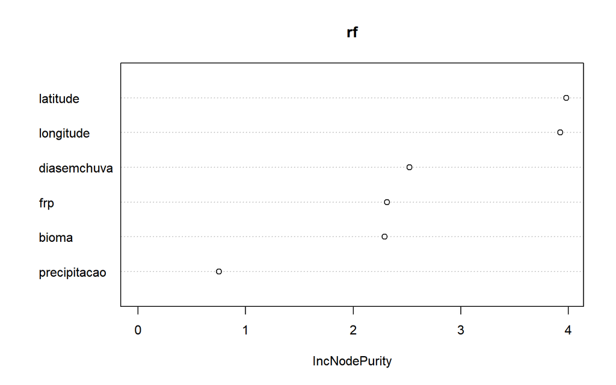

```r
varImpPlot(rf)
```

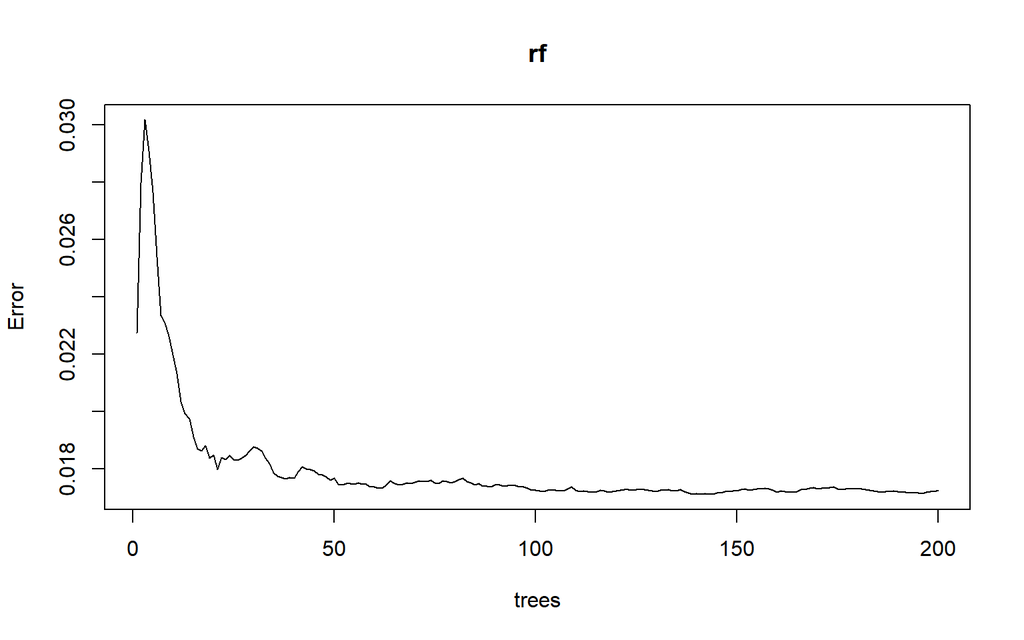

```r
plot(rf)
```

Testando o modelo Nº6(Decision Tree)

```r
teste_v6 <- dados_teste[,-c(1:5,9)] #retirando coluna de character e target
treino_v6 <- dados_treino[,-c(1:5)] #retirando coluna de character
```

```r
tree_1<-tree(riscofogo ~ bioma  + diasemchuva + precipitacao + latitude + longitude + frp, data = treino_v6)
```

```r
summary(tree_1)
```

```
##
## Regression tree:
## tree(formula = riscofogo ~ bioma + diasemchuva + precipitacao +
##     latitude + longitude + frp, data = treino_v6)
## Variables actually used in tree construction:
## [1] "bioma"       "diasemchuva" "latitude"    "longitude"
## Number of terminal nodes:  10
## Residual mean deviance:  0.01519 = 5.497 / 362
## Distribution of residuals:
##     Min.  1st Qu.   Median     Mean  3rd Qu.     Max.
## -0.57170 -0.06250  0.02827  0.00000  0.02827  0.70000
```

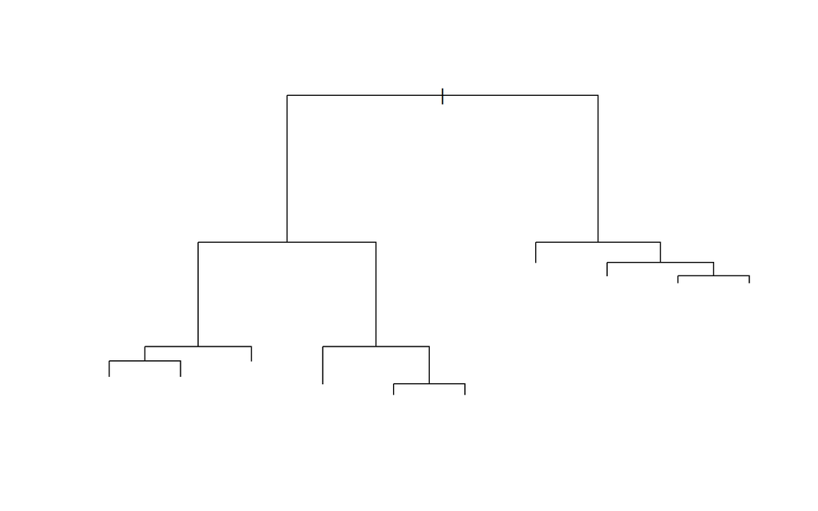

```r
plot(tree_1)
```

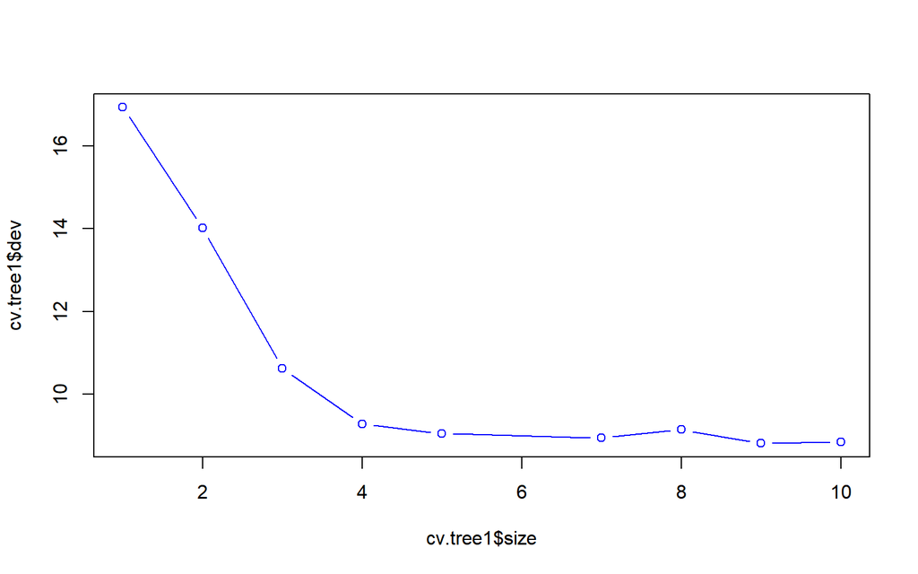

```r
cv.tree1<- cv.tree(tree_1)
plot(cv.tree1$size, cv.tree1$dev, type ="b", col="blue")
```

teste

```r
riscofogo_teste <- predict(tree_1,teste_v6  )
riscofogo_original <-dados_teste[,9]
```

```r
teste1 <- data.frame(obs=riscofogo_original, pred=riscofogo_teste)
str(teste1)
```

```
## 'data.frame':    249 obs. of  2 variables:
##  $ obs : num  1 0.8 0.5 0.4 0.2 0.8 0.7 1 1 1 ...
##  $ pred: num  0.785 0.972 0.785 0.972 0.972 ...
```

```r
str(teste1)
```

```
## 'data.frame':    249 obs. of  2 variables:
##  $ obs : num  1 0.8 0.5 0.4 0.2 0.8 0.7 1 1 1 ...
##  $ pred: num  0.785 0.972 0.785 0.972 0.972 ...
```

```r
prop.table(table(dados_treino$riscofogo)) * 100
```

```
##
##          0        0.1        0.2        0.3        0.4        0.5        0.6
##  1.0752688  1.6129032  1.0752688  0.2688172  1.6129032  0.8064516  5.6451613
##        0.7        0.8        0.9          1
##  6.9892473 10.7526882  6.9892473 63.1720430
```

```r
dados_treino$precipitacao = as.factor (dados_treino$precipitacao)
dados_treino$riscofogo = as.factor (dados_treino$riscofogo)
dados_treino$latitude  = as.factor (dados_treino$latitude )
dados_treino$longitude  = as.factor (dados_treino$longitude)
dados_treino$frp  = as.factor (dados_treino$frp )
```

aplicando balanceamento com SMOTE(não deu certo) dados_treino_balanceados <- SMOTE(riscofogo ~ ., dados_treino, perc.over = 600, perc.under = 100)